# Lab_1

Hunter Davis

2024-11-12

## Step One: Setting Up and Collecting Data

Install and library packages used for project

```r
install.packages("httr")
install.packages("jsonlite")
install.packages("tidyverse")
install.packages("corrplot")
library(httr)
library(jsonlite)
library(tidyverse)
library(corrplot)
```

Request data from the **OpenWeatherMap API**. Collected data from five locations (Amsterdam, Antigua, Berlin, London, and Vancouver) over a **five day** period. Loaded data directly into RStudio and specified temperatures to be in Fahrenheit.

```r
Van_Weather_Data <- httr::GET("https://api.openweathermap.org/data/2.5/forecast?lat=49.282730&lon=-123.120735&appid=54e9c511101dc7ddfb0ca46e5be71d2c&units=imperial",
                          httr::authenticate(
                            user = "", # My API key in user name field
                            password = "",
                            type = "basic"
                            ))

Lon_Weather_Data <- httr::GET("https://api.openweathermap.org/data/2.5/forecast?lat=51.507351&lon=-0.127758&appid=54e9c511101dc7ddfb0ca46e5be71d2c&units=imperial",
                              httr::authenticate(
                                user = "", # My API key in user name field
                                password = "",
                                type = "basic"
                              ))
Ber_Weather_Data <- httr::GET("https://api.openweathermap.org/data/2.5/forecast?lat=52.520008&lon=13.404954&appid=54e9c511101dc7ddfb0ca46e5be71d2c&units=imperial",
                              httr::authenticate(
                                user = "", # My API key in user name field
                                password = "",
                                type = "basic"
                              ))
Ams_Weather_Data <- httr::GET("https://api.openweathermap.org/data/2.5/forecast?lat=52.370216&lon=4.895168&appid=54e9c511101dc7ddfb0ca46e5be71d2c&units=imperial",
                              httr::authenticate(
                                user = "", # My API key in user name field
                                password = "",
                                type = "basic"
                              ))
Ant_Weather_Data <- httr::GET("https://api.openweathermap.org/data/2.5/forecast?lat=17.074656&lon=-61.817520&appid=54e9c511101dc7ddfb0ca46e5be71d2c&units=imperial",
                              httr::authenticate(
                                user = "", # My API key in user name field
                                password = "",
                                type = "basic"
                              ))
```

Viewed imported data and converted it into a usable format.

```r
# View API GET response result
str(Ams_Weather_Data)
str(Ant_Weather_Data)
str(Ber_Weather_Data)
str(Lon_Weather_Data)
str(Van_Weather_Data)


# View the main source of the data needed from the API - Normally content
str(Ams_Weather_Data$content)
str(Ant_Weather_Data$content)
str(Ber_Weather_Data$content)
str(Lon_Weather_Data$content)
str(Van_Weather_Data$content)

# Convert Raw content to text (in this case, a JSON string)
Ams_weather_content <- httr::content(Ams_Weather_Data, as = "text")
Ant_weather_content <- httr::content(Ant_Weather_Data, as = "text")
Ber_weather_content <- httr::content(Ber_Weather_Data, as = "text")
Lon_weather_content <- httr::content(Lon_Weather_Data, as = "text")
Van_weather_content <- httr::content(Van_Weather_Data, as = "text")

# View JSON String result
str(Ams_weather_content)
str(Ant_weather_content)
str(Ber_weather_content)
str(Lon_weather_content)
str(Van_weather_content)

# Convert the JSON string to a data frame and view
# data in a table
Ams_Weather_JSON <- jsonlite::fromJSON(Ams_weather_content)
Ant_Weather_JSON <- jsonlite::fromJSON(Ant_weather_content)
Ber_Weather_JSON <- jsonlite::fromJSON(Ber_weather_content)
Lon_Weather_JSON <- jsonlite::fromJSON(Lon_weather_content)
Van_Weather_JSON <- jsonlite::fromJSON(Van_weather_content)

View(Ams_Weather_JSON$list$main)
View(Ant_Weather_JSON$list$main)
View(Ber_Weather_JSON$list$main)
View(Lon_Weather_JSON$list$main)
View(Van_Weather_JSON$list$main)

# Create new data frames with weather data
Amsterdam_weather <- Ams_Weather_JSON$list$main
Antigua_weather <- Ant_Weather_JSON$list$main
Berlin_weather <- Ber_Weather_JSON$list$main
London_weather <- Lon_Weather_JSON$list$main
Vancouver_weather <- Van_Weather_JSON$list$main

# Update data frames for needed information
Amsterdam_weather <- Amsterdam_weather[ , names(Amsterdam_weather) %in% c("temp", "feels_like", "temp_min", "temp_max", "humidity")]
Antigua_weather <- Antigua_weather[ , names(Antigua_weather) %in% c("temp", "feels_like", "temp_min", "temp_max", "humidity")]
Berlin_weather <- Berlin_weather[ , names(Berlin_weather) %in% c("temp", "feels_like", "temp_min", "temp_max", "humidity")]
London_weather <- London_weather[ , names(London_weather) %in% c("temp", "feels_like", "temp_min", "temp_max", "humidity")]
Vancouver_weather <- Vancouver_weather[ , names(Vancouver_weather) %in% c("temp", "feels_like", "temp_min", "temp_max", "humidity")]
```

Had to pull wind speed and date and time separately because it was in a separate drop down in the data set format.

```r
Amsterdam_windspeed <- Ams_Weather_JSON$list$wind$speed
Antigua_windspeed <- Ant_Weather_JSON$list$wind$speed
Berlin_windspeed <- Ber_Weather_JSON$list$wind$speed
London_windspeed <- Lon_Weather_JSON$list$wind$speed
Vancouver_windspeed <- Van_Weather_JSON$list$wind$speed

# Combined weather data and wind speed data in to one data frame
Amsterdam_weather$Wind_Speed <- Amsterdam_windspeed
Antigua_weather$Wind_Speed <- Antigua_windspeed
Berlin_weather$Wind_Speed <- Berlin_windspeed
London_weather$Wind_Speed <- London_windspeed
Vancouver_weather$Wind_Speed <- Vancouver_windspeed

# Pull date and time
Amsterdam_dt <- Ams_Weather_JSON$list$dt_txt
Antigua_dt <- Ant_Weather_JSON$list$dt_txt
Berlin_dt <- Ber_Weather_JSON$list$dt_txt
London_dt <- Lon_Weather_JSON$list$dt_txt
Vancouver_dt <- Van_Weather_JSON$list$dt_txt

# Combined weather data and date and time data
Amsterdam_weather$Date_Time <- Amsterdam_dt
Antigua_weather$Date_Time <- Antigua_dt
Berlin_weather$Date_Time <- Berlin_dt
London_weather$Date_Time <- London_dt
Vancouver_weather$Date_Time <- Vancouver_dt

# get column names
colnames(Amsterdam_weather)
colnames(Antigua_weather)
colnames(Berlin_weather)
colnames(London_weather)
colnames(Vancouver_weather)
```

## Step Two: Data Transformation and Analysis

```r
# Rename columns to clean up look.
Amsterdam_weather <- Amsterdam_weather %>%
  rename(
    Temp = temp,
    Feels_Like = feels_like,
    Temp_Min = temp_min,
    Temp_Max = temp_max,
    Humidity = humidity
  )

Antigua_weather <- Antigua_weather %>%
  rename(
    Temp = temp,
    Feels_Like = feels_like,
    Temp_Min = temp_min,
    Temp_Max = temp_max,
    Humidity = humidity
  )

Berlin_weather <- Berlin_weather %>%
  rename(
    Temp = temp,
    Feels_Like = feels_like,
    Temp_Min = temp_min,
    Temp_Max = temp_max,
    Humidity = humidity
  )

London_weather <- London_weather %>%
  rename(
    Temp = temp,
    Feels_Like = feels_like,
    Temp_Min = temp_min,
    Temp_Max = temp_max,
    Humidity = humidity
  )

Vancouver_weather <- Vancouver_weather %>%
  rename(
    Temp = temp,
    Feels_Like = feels_like,
    Temp_Min = temp_min,
    Temp_Max = temp_max,
    Humidity = humidity
  )

# adding a new column to each data frame to specify location
Amsterdam_weather <- Amsterdam_weather %>%
     mutate(City = "Amsterdam")

Antigua_weather <- Antigua_weather %>%
     mutate(City = "Antigua")

Berlin_weather <- Berlin_weather %>%
     mutate(City = "Berlin")

London_weather <- London_weather %>%
     mutate(City = "London")

Vancouver_weather <- Vancouver_weather %>%
     mutate(City = "Vancouver")
```

Merge data frames together.

```r
# Merge data frames together
Weather_All <- rbind(Amsterdam_weather, Antigua_weather, Berlin_weather, London_weather, Vancouver_weather)
```

Reorganize columns and rename the column City to Location. Additionally change the Date_Time column to an actual date and time, and separate them into their own columns and reorganize.

```r
colnames(Weather_All)

#reorganize column headers
Weather_All <- Weather_All[,c(7,8,1,2,3,4,5,6)]

# Check data type
sapply(Weather_All, class)

# change date_time into a time object and not
# a character one
Weather_All$Date_Time <- strptime(Weather_All$Date_Time, format = "%Y-%m-%d %H:%M:%S", tz=Sys.timezone())

#Change City header to Location
Weather_All <- Weather_All %>%
  rename(
    Location = City,
  )

# Split the Date_Time column
Weather_All$Date <- as.Date(Weather_All$Date_Time)               # Add date column
Weather_All$Time <- format(as.POSIXct(Weather_All$Date_Time),    # Add time column
                    format = "%H:%M:%S")

Weather_All <- Weather_All[,c(1, 9, 10, 3, 4, 5, 6, 7, 8)]
```

Repeat the following steps for the individual locations.

```r
Amsterdam_weather$Date <- as.Date(Amsterdam_weather$Date_Time)               # Add date column
Amsterdam_weather$Time <- format(as.POSIXct(Amsterdam_weather$Date_Time),    # Add time column
                           format = "%H:%M:%S")

Antigua_weather$Date <- as.Date(Antigua_weather$Date_Time)               # Add date column
Antigua_weather$Time <- format(as.POSIXct(Antigua_weather$Date_Time),    # Add time column
                                 format = "%H:%M:%S")

Berlin_weather$Date <- as.Date(Berlin_weather$Date_Time)               # Add date column
Berlin_weather$Time <- format(as.POSIXct(Berlin_weather$Date_Time),    # Add time column
                                 format = "%H:%M:%S")

London_weather$Date <- as.Date(London_weather$Date_Time)               # Add date column
London_weather$Time <- format(as.POSIXct(London_weather$Date_Time),    # Add time column
                                 format = "%H:%M:%S")

Vancouver_weather$Date <- as.Date(Vancouver_weather$Date_Time)               # Add date column
Vancouver_weather$Time <- format(as.POSIXct(Vancouver_weather$Date_Time),    # Add time column
                                 format = "%H:%M:%S")

# Reorganize
Amsterdam_weather <- Amsterdam_weather[,c(7, 9, 10, 1, 2, 3, 4, 5, 6)]
Antigua_weather <- Antigua_weather[,c(7, 9, 10, 1, 2, 3, 4, 5, 6)]
Berlin_weather <- Berlin_weather[,c(7, 9, 10, 1, 2, 3, 4, 5, 6)]
London_weather <- London_weather[,c(7, 9, 10, 1, 2, 3, 4, 5, 6)]
Vancouver_weather <- Vancouver_weather[,c(7, 9, 10, 1, 2, 3, 4, 5, 6)]
```

```r
# Pull aggregate data from individual data frames
# Mean temp
tapply(Amsterdam_weather$Temp, Amsterdam_weather$Date, mean)
tapply(Antigua_weather$Temp, Antigua_weather$Date, mean)
tapply(Berlin_weather$Temp, Berlin_weather$Date, mean)
tapply(London_weather$Temp, London_weather$Date, mean)
tapply(Vancouver_weather$Temp, Vancouver_weather$Date, mean)
```

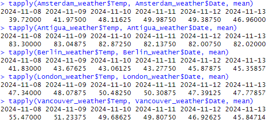

Average temperature per day by location

```r
# Max temp
tapply(Amsterdam_weather$Temp, Amsterdam_weather$Date, max)
tapply(Antigua_weather$Temp, Antigua_weather$Date, max)
tapply(Berlin_weather$Temp, Berlin_weather$Date, max)
tapply(London_weather$Temp, London_weather$Date, max)
tapply(Vancouver_weather$Temp, Vancouver_weather$Date, max)
```

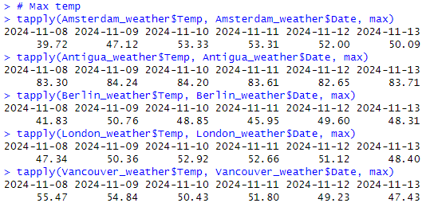

Max temperature per day by location

```r
# Min temp
tapply(Amsterdam_weather$Temp, Amsterdam_weather$Date, min)
tapply(Antigua_weather$Temp, Antigua_weather$Date, min)
tapply(Berlin_weather$Temp, Berlin_weather$Date, min)
tapply(London_weather$Temp, London_weather$Date, min)
tapply(Vancouver_weather$Temp, Vancouver_weather$Date, min)
```

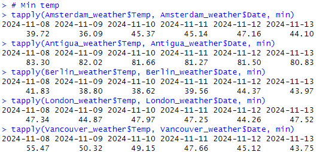

Min temperature per day by location

```r
# Mean humidity
tapply(Amsterdam_weather$Humidity, Amsterdam_weather$Date, mean)
tapply(Antigua_weather$Humidity, Antigua_weather$Date, mean)
tapply(Berlin_weather$Humidity, Berlin_weather$Date, mean)
tapply(London_weather$Humidity, London_weather$Date, mean)
tapply(Vancouver_weather$Humidity, Vancouver_weather$Date, mean)
```

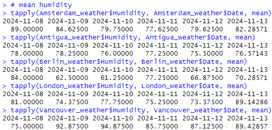

Average humidity level per day by location

```r
# Max humidity
tapply(Amsterdam_weather$Humidity, Amsterdam_weather$Date, max)
tapply(Antigua_weather$Humidity, Antigua_weather$Date, max)
tapply(Berlin_weather$Humidity, Berlin_weather$Date, max)
tapply(London_weather$Humidity, London_weather$Date, max)
tapply(Vancouver_weather$Humidity, Vancouver_weather$Date, max)
```

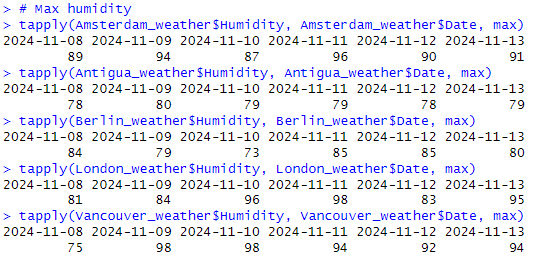

Max humidity level per day by location

```r
# Min humidity
tapply(Amsterdam_weather$Humidity, Amsterdam_weather$Date, min)
tapply(Antigua_weather$Humidity, Antigua_weather$Date, min)
tapply(Berlin_weather$Humidity, Berlin_weather$Date, min)
tapply(London_weather$Humidity, London_weather$Date, min)
tapply(Vancouver_weather$Humidity, Vancouver_weather$Date, min)
```

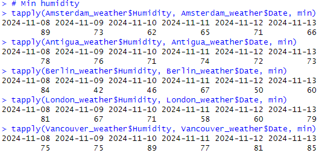

Min humidity level per day by location

```r
# Mean wind speed
tapply(Amsterdam_weather$Wind_Speed, Amsterdam_weather$Date, mean)
tapply(Antigua_weather$Wind_Speed, Antigua_weather$Date, mean)
tapply(Berlin_weather$Wind_Speed, Berlin_weather$Date, mean)
tapply(London_weather$Wind_Speed, London_weather$Date, mean)
tapply(Vancouver_weather$Wind_Speed, Vancouver_weather$Date, mean)
```

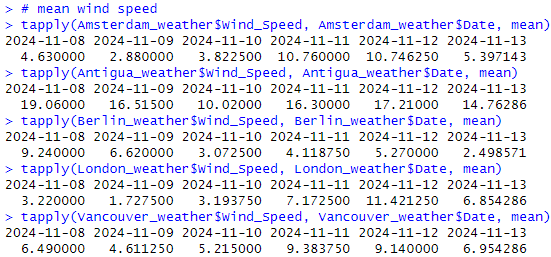

Average wind speed per day by location

```r
# Max wind speed
tapply(Amsterdam_weather$Wind_Speed, Amsterdam_weather$Date, max)
tapply(Antigua_weather$Wind_Speed, Antigua_weather$Date, max)
tapply(Berlin_weather$Wind_Speed, Berlin_weather$Date, max)
tapply(London_weather$Wind_Speed, London_weather$Date, max)
tapply(Vancouver_weather$Wind_Speed, Vancouver_weather$Date, max)
```

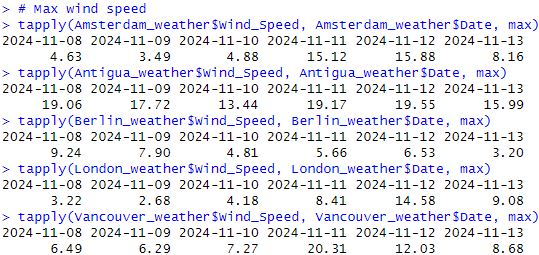

Max wind speed per day by location

```r
# Min wind speed
tapply(Amsterdam_weather$Wind_Speed, Amsterdam_weather$Date, min)
tapply(Antigua_weather$Wind_Speed, Antigua_weather$Date, min)
tapply(Berlin_weather$Wind_Speed, Berlin_weather$Date, min)
tapply(London_weather$Wind_Speed, London_weather$Date, min)
tapply(Vancouver_weather$Wind_Speed, Vancouver_weather$Date, min)
```

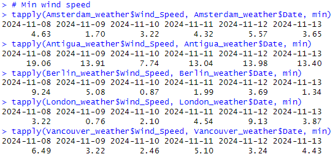

Min wind speed per day by location

## Step Three: Data Visualization

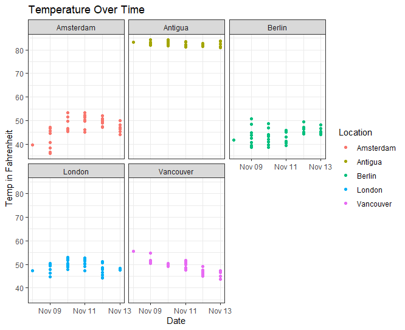

plot of temperatures over time by location

```r
# Graphs
ggplot(data = Weather_All ,
       mapping = aes(x = Date,
                     y = Temp,
                     color = Location))+
  geom_point()+
  facet_wrap(~Location)+
  labs(title = "Temperature Over Time",
       x = "Date",
       y = "Temp in Fahrenheit")+
  theme_bw()
```

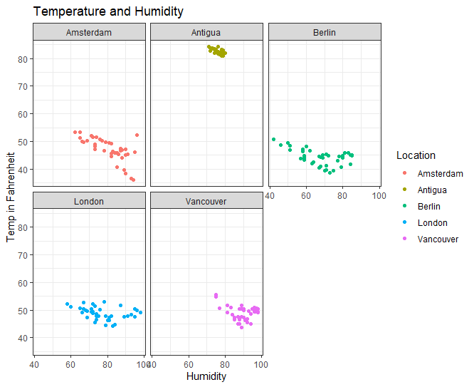

plot of temperature compared to humidity by location

```r
ggplot(data = Weather_All ,
       mapping = aes(x = Humidity,
                     y = Temp,
                     color = Location))+
  geom_point()+
  facet_wrap(~Location)+
  labs(title = "Temperature and Humidity",
       x = "Humidity",
       y = "Temp in Fahrenheit")+
  theme_bw()
```

[figure not shown]

plot comparing temperature to wind speed by location

```r
ggplot(data = Weather_All ,
       mapping = aes(x = Wind_Speed,
                     y = Temp,
                     color = Location))+
  geom_point()+
  facet_wrap(~Location)+
  labs(title = "Temperature and Wind Speed",
       x = "Wind Speed (meter/second)",
       y = "Temp in Fahrenheit")+
  theme_bw()
```

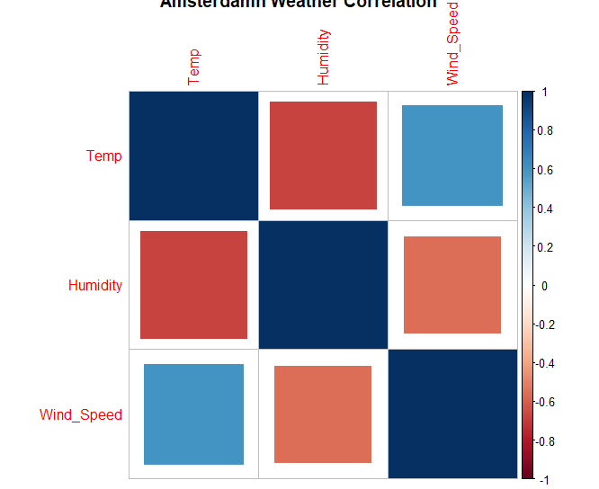

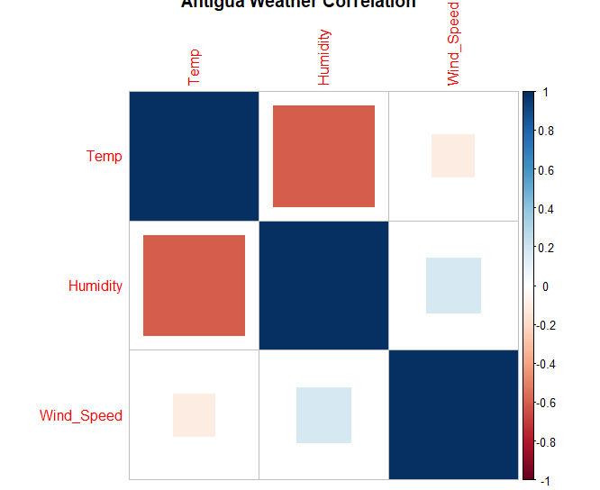

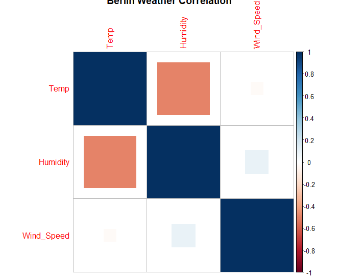

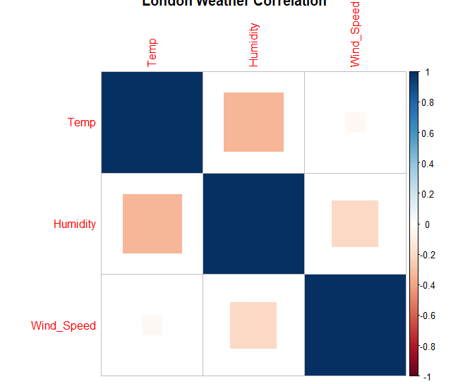

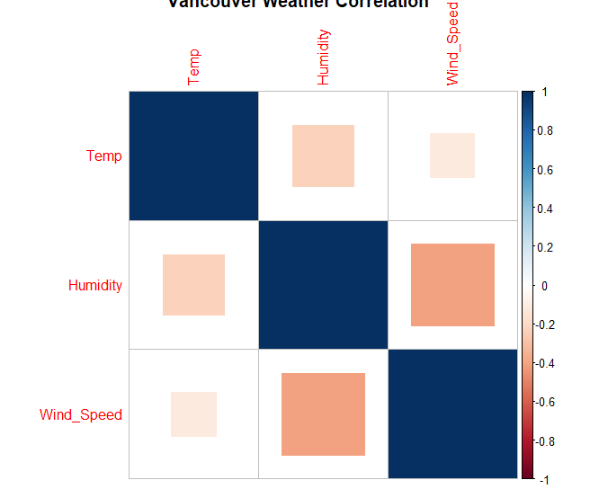

```r
# create a data frame of just temp, humidity, and wind speed
# Individual location correlation data
Cor_Ams <- Amsterdam_weather[,c(4, 8, 9)]
Cor_Ant <- Antigua_weather[,c(4, 8, 9)]
Cor_Ber <- Berlin_weather[,c(4, 8, 9)]
Cor_Lon <- London_weather[,c(4, 8, 9)]
Cor_Van <- Vancouver_weather[,c(4, 8, 9)]

# Correlation graph
corrplot(cor(Cor_Ams), method = "square",
         title = "Amsterdamn Weather Correlation")
corrplot(cor(Cor_Ant), method = "square",
         title = "Antigua Weather Correlation")
corrplot(cor(Cor_Ber), method = "square",
         title = "Berlin Weather Correlation")
corrplot(cor(Cor_Lon), method = "square",
         title = "London Weather Correlation")
corrplot(cor(Cor_Van), method = "square",
         title = "Vancouver Weather Correlation")
```

# Step Four: Insight Generation

## Data Interpretation:

Based on the data acquired for the five locations The tourist company is offering trip plans for we can say the following concerning the weather patterns.

## Redommendations

Based on the data collected and the insights extracted I would recommend the tourist company promote these five locations and advise their customers on the following.

### Antigua

**Best Time to Visit**: Winter and spring.

Antigua is the spot to be for those customers that want to experience the sun and the sea to their fullest. It has hot winters and hotter summers which makes it a great destination for escaping harsh winters. Definitely swimwear and shorts are a must when traveling to Antigua to experience all the Island has to offer with its 365 beaches. With the strong winds it’s a great location for parasailing, sail boating, and sailboarding.

### Berlin

**Best Time to Visit**: Fall and Winter

Berlin in November is a cool environments with high humidity which has the makings for a beautiful winter vacation. Although it is unlikely for snowfall until further into December the mild temperatures and low wind speeds could be very attractive to those customers in more extreme heat looking to cool off, but not too much. Plan for the cold by packing extra layers and cold weather clothing. Berlins a great location in the fall and winter to touring the historic sites and enjoying the traditional foods and drinks to stay warm while enjoying the fresh cool air.

### Amsterdam, London, Vancouver

**Best Time to Visit**: Fall and Spring

Amsterdam, London, and Vancouver are all very similar in temperature, humidity, and wind speed. Much like Berlin they are great cold weather destinations for those looking to escape the heat and experience the winter season. What make these locations different is their wind speeds which contribute to the temperatures feeling colder then they actually are. Pack cold weather cloths and remember to bring your knit cap and scarf to save your ears and nose. All three cities have plenty to do that will keep the cold away as you explore the sights and experience the multicultural restaurants.